# ICU Patient In-hospital Death Prediction

> OBJECTIVE
1. Predict in-hospital death among patients admitted to the ICU
2. Deploy interpretable machine learning algorithms: LR and decision trees
3. Conduct association analysis and predictive analysis

#### Features:

- Outcome: hospital expire flag
- Features to consider:
  - age at death
  - gender
  - ethnicity
  - type of insurance
  - source of admission
  - type of admission
  - the number of ICU admissions
  - age at icu admission
  - the number of hospital admissions
  - the number of assigned icd9 codes

```r
# load required package
loadlibs = function(libs) {
  for(lib in libs) {
    class(lib)
    if(!do.call(require,as.list(lib))) {install.packages(lib)}
    do.call(require,as.list(lib))
  }
}
libs = c("tidyr","magrittr","purrr","dplyr","stringr","readr","data.table", "lubridate","ggplot2","modelr","rpart","ROCR","rpart.plot","knitr","broom","kableExtra")
mycol <- c('#8dd3c7','#ffffb3','#bebada','#fb8072','#80b1d3','#fdb462','#b3de69','#fccde5','#d9d9d9','#bc80bd')

loadlibs(libs)

# read three files
demographic <- read_csv("demographic_detail.csv")
icd9 <- read_csv("icd9.csv")
icu.stay <- read_csv("icustay_detail.csv")
```

#### Data Preprocessing

```r
# create new column:age
icu.stay.select <- icu.stay %>%
  mutate(icustay_admit_age = round(icustay_admit_age,0),
         age = year(dod)-year(dob)) %>%
  select(hospital_expire_flg,gender,subject_id, hadm_id, icustay_total_num, icustay_admit_age, age) %>% unique()

# in icd9, count the total assigned code for each patient and each hospitalization
# join demographic, icu.stay and icd9 data frame
# in joined data frame, create two columns: cumulative hospitalization and cumulative assigned code for each patient
allpatient <- left_join(demographic,icu.stay.select,by=c("subject_id","hadm_id"))
allpatient = allpatient %>%
  arrange(subject_id,hadm_id)
icd9 = icd9 %>%
  group_by(subject_id,hadm_id) %>%
  summarise(ttlCode=length(code)) %>%
  arrange(subject_id,hadm_id) %>% as.data.frame()
allpatient = left_join(allpatient,icd9,by=c("subject_id","hadm_id"))
allpatient = allpatient %>%
  group_by(subject_id) %>%
  mutate(number_hadm = seq(1,length(hadm_id)),
         number_code = cumsum(ttlCode)) %>% as.data.frame()

# remove duplicated data and select some columns
uniqueid = unique(allpatient) %>% as.data.frame()
uniqueid = uniqueid %>%
  select(subject_id,hadm_id,ethnicity_descr,overall_payor_group_descr,admission_type_descr,admission_source_descr,icustay_total_num,icustay_admit_age,number_code,number_hadm,age,hospital_expire_flg,gender)
uniqueid = uniqueid %>%
  filter(!ethnicity_descr %in% c('AMERICAN INDIAN/ALASKA NATIVE','ASIAN - CHINESE','BLACK/CAPE VERDEAN','MULTI RACE ETHNICITY','UNABLE TO OBTAIN','ASIAN - VIETNAMESE','BLACK/HAITIAN',
'HISPANIC/LATINO - PUERTO RICAN','NATIVE HAWAIIAN OR OTHER PACIFIC ISLAND','WHITE - RUSSIAN'))

# transform some columns into factor
for(i in c(3:6,12,13)){
  uniqueid[,i] <- as.factor(uniqueid[[i]])
}

# Other cleanning:
# 1. if age is NA, attach the overall median
# 2. if there is no number_code , then set to 0
# 3. remove observations without label(hospital_expire_flg)
# 4. remove NA gender
# 5. remove categories with few observations
uniqueid$age[is.na(uniqueid$age)] <- median(uniqueid$age,na.rm=T)
uniqueid$number_code[is.na(uniqueid$number_code)] <- 0
uniqueid = uniqueid %>%
  filter(!is.na(hospital_expire_flg))
uniqueid = uniqueid %>%
    filter(!is.na(gender))
uniqueid = uniqueid %>%
    filter(!admission_source_descr %in% c("** INFO NOT AVAILABLE **","HMO REFERRAL/SICK"))
```

#### Descriptive Summary

- Age  
  Among patient admitted to ICU, death rate of newborn is 100%

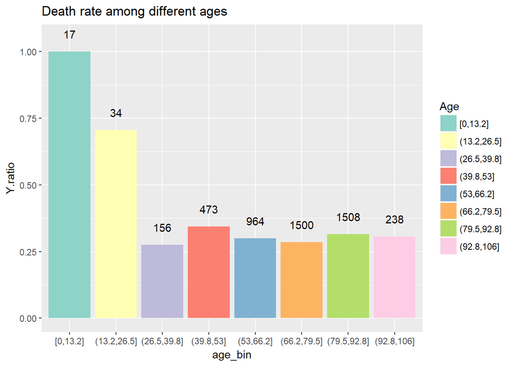

```r
uniqueid$age_bin <- cut_interval(uniqueid$age, n = 8)
uniqueid %>%
    group_by(age_bin) %>%
    summarize(Y.ratio = sum(as.numeric(hospital_expire_flg)-1)/length(hospital_expire_flg),
              N = length(hospital_expire_flg)) %>%
    ggplot(aes(x=age_bin, y=Y.ratio, fill=age_bin)) +
    geom_text(aes(label = N, y = Y.ratio + 0.05),position = position_dodge(0.9), vjust = 0)+
    geom_bar(stat='identity') +
    scale_fill_manual(values=mycol) +
    guides(fill=guide_legend(title="Age"))+
    ggtitle("Death rate among different ages")
```

- type of insurance  
  Self-pay patients have the highest death rate.

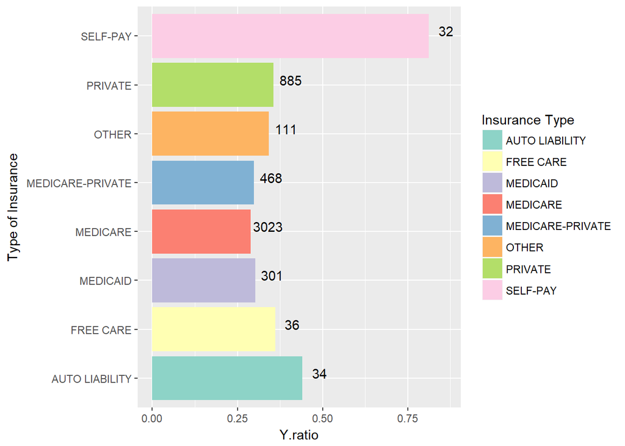

```r
uniqueid %>%
  group_by(overall_payor_group_descr) %>%
  summarise(Y.ratio = sum((as.numeric(hospital_expire_flg)-1))/length(hospital_expire_flg),
            N = length(hospital_expire_flg)) %>%
  ggplot(aes(x =overall_payor_group_descr,y=Y.ratio,fill=overall_payor_group_descr)) +
  geom_text(aes(label = N, y = Y.ratio + 0.05),position = position_dodge(0.9), vjust = 0)+
  geom_bar(stat='identity') +
  coord_flip()+
  guides(fill=guide_legend(title="Insurance Type"))+
  scale_fill_manual(values=mycol)+
  labs(x='Type of Insurance')
```

- Number of ICU Admission  
  Few patients have more than four times ICU admission.The more ICU stay, the higer in-hospital death rate.

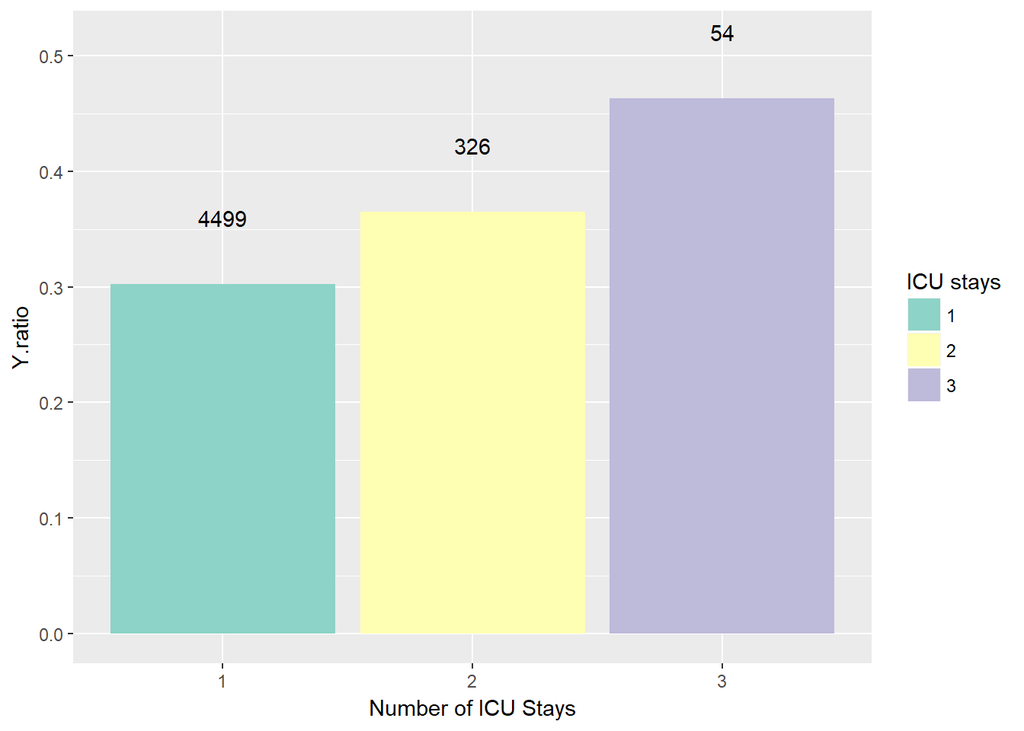

```r
uniqueid %>%
  filter(icustay_total_num < 4) %>%
    group_by(icustay_total_num) %>%
    summarize(Y.ratio = sum(as.numeric(hospital_expire_flg)-1)/length(hospital_expire_flg),
              N = length(hospital_expire_flg)) %>%
    ggplot(aes(x=as.factor(icustay_total_num), y=Y.ratio, fill=as.factor(icustay_total_num))) +
    geom_text(aes(label = N, y = Y.ratio + 0.05),position = position_dodge(0.9), vjust = 0)+
    geom_bar(stat='identity') +
    guides(fill=guide_legend(title="ICU stays"))+
    scale_fill_manual(values=mycol)+
  labs(x="Number of ICU Stays")
```

- Number of Hospital Admission  
  Patients admitted by hospital once have the highest rate of death.

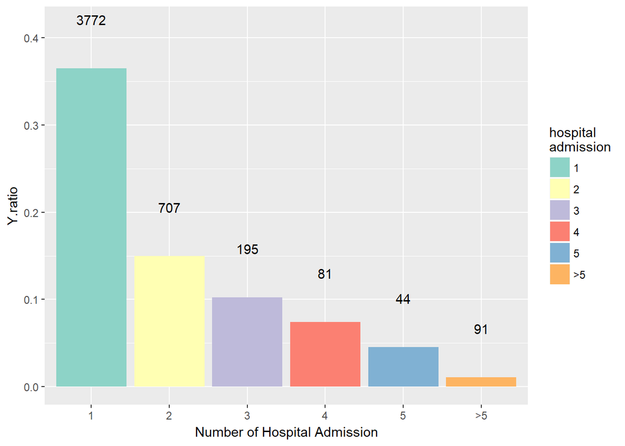

```r
# number of hospital admission
uniqueid$number_hadm_bin <- cut(uniqueid$number_hadm, breaks = c(seq(0,5), Inf), labels = c(as.character(seq(1,5)), ">5"))

uniqueid %>%
    group_by(number_hadm_bin) %>%
    summarize(Y.ratio = sum(as.numeric(hospital_expire_flg)-1)/length(hospital_expire_flg),
              N = length(hospital_expire_flg)) %>%
    ggplot(aes(x=number_hadm_bin, y=Y.ratio, fill=number_hadm_bin)) +
    geom_text(aes(label = N, y = Y.ratio + 0.05),position = position_dodge(0.9), vjust = 0)+
    geom_bar(stat='identity') +
    guides(fill=guide_legend(title="hospital\nadmission"))+
    scale_fill_manual(values=mycol)+
  labs(x="Number of Hospital Admission")
```

#### Logistic Regression

Based on the initial data visualization, choose variables that are associated with the response variable.  
1. age  
2. overall_payor_group_descr  
3. admission_source_descr 4. admission_type_descr  
5. icustay_total_num  
6. icustay_admit_age  
7. number_code  
8. number_hadm

Features that are statistically significant:  
1. Admission source from emergency room,hospital,other health institution  
2. age 3. insurance type: self-pay  
4. Admission type: emergency, urgent  
5. the number of ICU admissions  
6. the number of hospital admissions  
7. the number of assigned icd9 codes

```r
# train:test = 8:2
set.seed(123)
i.train <- sample(seq(1,nrow(uniqueid)), nrow(uniqueid)*0.8)
Xtrain <- uniqueid[i.train,]
Xtest <- uniqueid[-i.train,]

# fit the logistic regression
lr = with(Xtrain,glm(hospital_expire_flg=='Y'~admission_source_descr+age+overall_payor_group_descr+admission_type_descr+icustay_total_num+number_code+number_hadm,family = binomial("logit")))
lr_coef <- tidy(lr)[,c("term","p.value")]
lr_coef[lr_coef$p.value<0.05,] %>%
  mutate(p.value = round(p.value,4)) %>% kable("html") %>%
  kable_styling(bootstrap_options="striped",full_width=F)
```

| term | p.value |
| --- | --- |
| admission_source_descrEMERGENCY ROOM ADMIT | 0.0000 |
| admission_source_descrTRANSFER FROM HOSP/EXTRAM | 0.0002 |
| admission_source_descrTRANSFER FROM OTHER HEALT | 0.0038 |
| age | 0.0058 |
| overall_payor_group_descrSELF-PAY | 0.0136 |
| admission_type_descrEMERGENCY | 0.0024 |
| admission_type_descrURGENT | 0.0023 |
| icustay_total_num | 0.0039 |
| number_code | 0.0000 |
| number_hadm | 0.0000 |

#### Decision Tree

Fit the same predictors in a decision tree and plot the tree

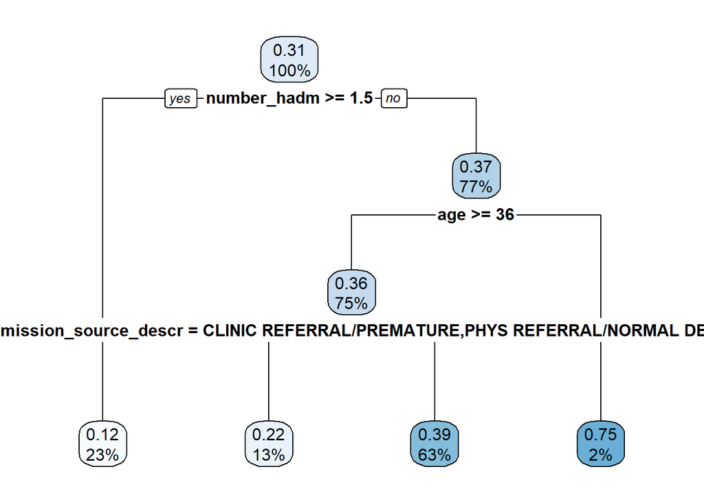

```r
tree <- rpart(hospital_expire_flg=="Y"~ admission_source_descr+age+overall_payor_group_descr+admission_type_descr+icustay_total_num+number_code+number_hadm,data=Xtrain, control=rpart.control(minsplit = 50))
rpart.plot(tree)
```

#### Logistic Regression with Cross-Validation

Use k-fold cross validation with k=5

```r
# validation preparation
set.seed(456)
folds = sample(rep(1:5,length=nrow(uniqueid)))
idx = seq_len(nrow(uniqueid))
uniqueid$index <- seq_len(nrow(uniqueid))
cv = cbind(idx,folds) %>% as_tibble() %>% nest(-folds)
cv = cv %>%
  arrange(folds) %>%
  mutate(data = map(data, ~ .x %>% t() %>% c())) %>%
  mutate(train = map(data, ~uniqueid %>% filter(!index %in% .x))) %>%
  mutate(test = map(data,~uniqueid %>% filter(index %in% .x)))

# fit the logistic model
lr.cv.model = cv %>%
  mutate(lr = map(train,~glm(hospital_expire_flg=="Y" ~ admission_source_descr+age+overall_payor_group_descr+admission_type_descr+icustay_total_num+number_code+number_hadm, data=.x,family = binomial("logit")))) %>%
  mutate(prediction = map2(lr,test,~predict(.x,newdata=.y,type='response'))) %>%
  mutate(prediction = map(prediction,~ifelse(.x>0.3,1,0))) %>%
  mutate(truth = map(test, ~ifelse(.x$hospital_expire_flg=='Y',1,0)))
```

Average AUC,Accuracy,Sensitivity,Specificity,Precision,Recall:

```r
# confusion matrix
classification_metric <- function(actual_class, predicted_class){
    res = list()
    conf_mat = table(actual_class, predicted_class)
    TN = conf_mat[1,1]
    FN = conf_mat[1,2]
    FP = conf_mat[2,1]
    TP = conf_mat[2,2]

    res[["accuracy"]] = (TN+TP)/(TN+FN+FP+TP)
    res[["sensitivity"]] = (TP)/(TP+FN)
    res[["specificity"]] = (TN)/(TN+FP)
    res[["precision"]] = (TP)/(TP+FP)
    res[["recall"]] = (TP)/(TP+FN) # same as sensitivity

    return(res)
}

# average auc,accuracy,sensitivity,specificity,precision,recall
for(i in 1:nrow(lr.cv.model)){
  ret = classification_metric(lr.cv.model$truth[i]%>%unlist(),lr.cv.model$prediction[i]%>%unlist()) %>% as_tibble()
  if(i==1){
    measurement = ret
  }else{
    measurement = rbind(measurement,ret)
  }
}

lapply(measurement,mean) %>% as_tibble() %>% kable() %>% kable_styling(full_width = F,bootstrap_options = 'stripe')
```

| accuracy | sensitivity | specificity | precision | recall |
| --- | --- | --- | --- | --- |
| 0.5529652 | 0.3936401 | 0.8482049 | 0.8266251 | 0.3936401 |

Plot the ROC curve:AUC is 0.63

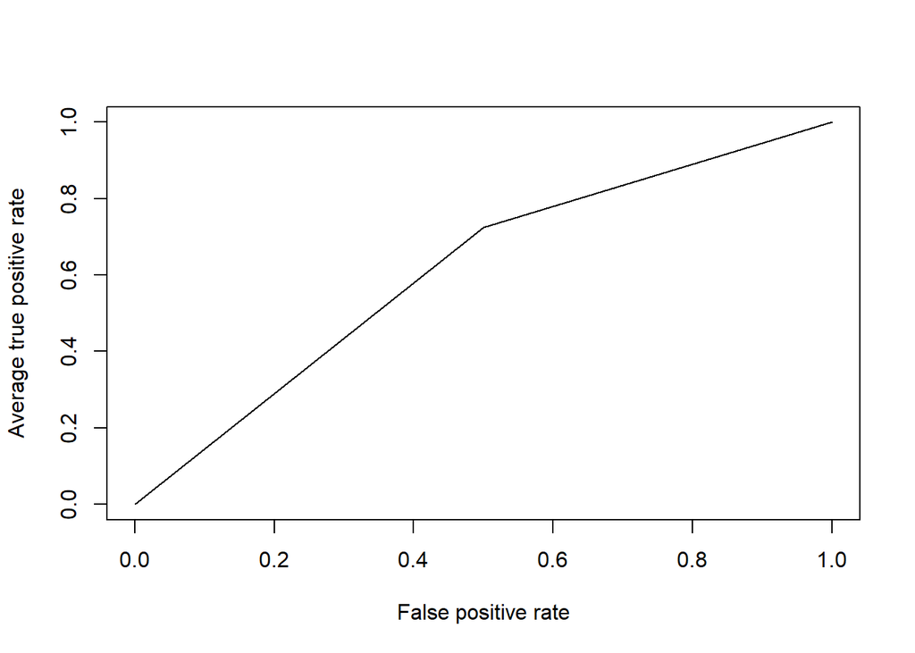

```r
lr_pred = ROCR::prediction(lr.cv.model$prediction,lr.cv.model$truth)
lr_rates = ROCR::performance(lr_pred,"tpr","fpr")
lr_auc = mean(ROCR::performance(lr_pred,"auc")@y.values %>% unlist())
plot(lr_rates,avg="vertical",pin=c(10,10))
```

#### Decision tree with Cross-Validation

Use k-fold cross validation with k=5

```r
tree.cv.model = cv %>%
  mutate(tree = map(train,~rpart(hospital_expire_flg=="Y" ~ admission_source_descr+age+overall_payor_group_descr+admission_type_descr+icustay_total_num+icustay_admit_age+number_code+number_hadm, data=.x,control=rpart.control(minsplit = 50)))) %>%
  mutate(prediction = map2(tree,test,~predict(.x,newdata=.y,type='vector'))) %>%
  mutate(prediction = map(prediction,~ifelse(.x>0.3,1,0))) %>%
  mutate(truth = map(test, ~ifelse(.x$hospital_expire_flg=='Y',1,0)))
```

Average AUC,Accuracy,Sensitivity,Specificity,Precision,Recall:

```r
for(i in 1:nrow(tree.cv.model)){
  ret.tree = classification_metric(tree.cv.model $truth[i]%>%unlist(),tree.cv.model $prediction[i]%>%unlist()) %>% as_tibble()
  if(i==1){
    measurement.tree = ret.tree
  }else{
    measurement.tree = rbind(measurement.tree,ret.tree)
  }
}

lapply(measurement.tree,mean) %>% as_tibble() %>% kable() %>% kable_styling(bootstrap_options = 'stripe',full_width = F)
```

```
## Currently generic markdown table using pandoc is not supported.
```

| accuracy | sensitivity | specificity | precision | recall |
| --- | --- | --- | --- | --- |
| 0.5280164 | 0.3843159 | 0.8732108 | 0.8777517 | 0.3843159 |

Plot the ROC curve: AUC is 0.62

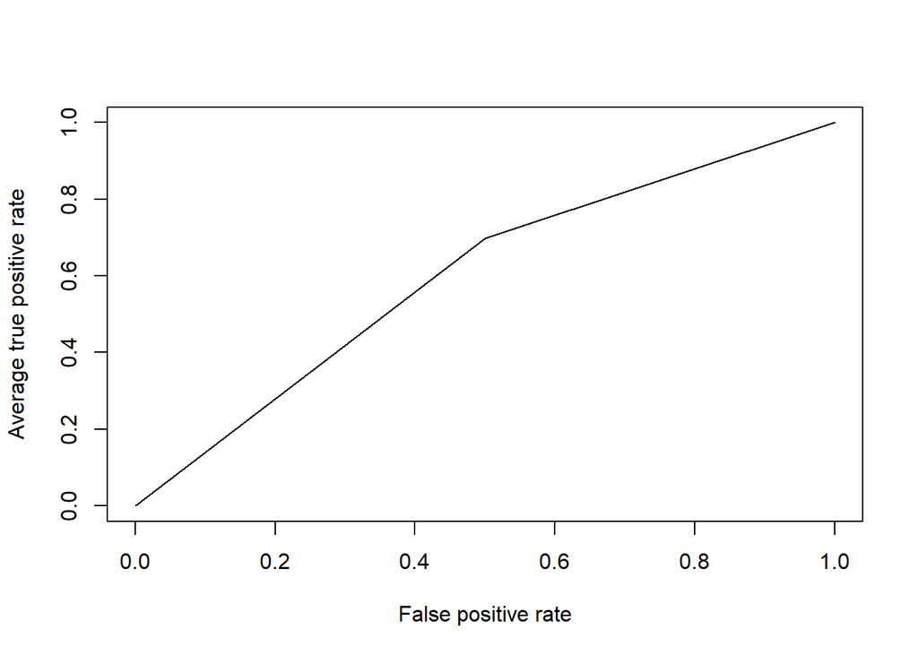

```r
tree_pred = ROCR::prediction(tree.cv.model$prediction,tree.cv.model$truth)
tree_rates = ROCR::performance(tree_pred,"tpr","fpr")
tree_auc = mean(ROCR::performance(tree_pred,"auc")@y.values %>% unlist())
plot(tree_rates,avg="vertical",pin=c(10,10))
```

#### Application

Estimate the odds and probability of in-hospital death for a patient with following features using the trained LR model.  
* age at death: 61  
* gender: M  
* ethnicity (ethnicity_descr): WHITE  
* type of insurance (overall_payor_group_descr): PRIVATE  
* source of admission (admission_source_descr): PHYS REFERRAL/NORMAL DELI  
* type of admission (admission_type_descr): URGENT  
* the number of ICU admissions (icustay_total_num): 1  
* age at icu admission (icu_admit_age): 58  
* the number of hospital admissions: 2  
* the number of assigned icd9 codes: 11

The probability of death for this particular patient is 0.13.  
And the odds is 0.15.

```r
tmp <- uniqueid[1,]
tmp$age <- 61
tmp$gender <- "M"
tmp$ethnicity_descr <- "WHITE"
tmp$overall_payor_group_descr <- "PRIVATE"
tmp$admission_source_descr <- "PHYS REFERRAL/NORMAL DELI"
tmp$admission_type_descr <- "URGENT"
tmp$icustay_total_num <- 1
tmp$icustay_admit_age <- 58
tmp$number_hadm <- 2
tmp$number_code <- 11
# lr is from step b
tmp_preds=predict(lr,tmp,type='response')
odds <- tmp_preds/(1-tmp_preds)
```